# Monte Carlo Investigation: The Exponential Population

Author

Pui Yin Lim

## 1. Population & Theoretical Baseline

- **Population Distribution:** Exponential Distribution with rate parameter $\lambda = 1$, generated via `rexp(n, rate = 1)`.
- **Characteristics:** It is a continuous distribution characterized by a strong right (positive) skew and an exponential decay shape starting at zero.
- **Theoretical Mean (**$\mu$): $\mu = \frac{1}{\lambda} = 1$
- **Theoretical Standard Deviation (**$\sigma$): $\sigma = \frac{1}{\lambda} = 1$
- **Theoretical Standard Error (**$\text{SE}$): $\frac{\sigma}{\sqrt{n}} = \frac{1}{\sqrt{n}}$

## 2. Expectations Before Simulation

While the underlying population is heavily skewed to the right rather than symmetric it’s likely to yield a sampling distribution that retains a noticeable right tail. The CLT guarantees convergence to normality as $n$ grows, however, because of the sharp initial skew, it’s predicted a larger sample size of, around $n = 30$ to $n = 50$ is required before the distribution satisfies a “normal enough” standard.

## 3. Simulation Setup & Execution

Simulating $B = 10,000$ Monte Carlo repetitions across sample sizes $n \in \{5, 10, 30, 50\}$ to observe how a heavily skewed distribution converges to normality via the Central Limit Theorem.

```r
library(tidyverse)
library(knitr)

theo_sigma <- 1

# Create a data frame for the explanation table
exp_explanation_table <- tibble(
  Sample_Size = c("n = 5", "n = 10", "n = 30", "n = 50"),
  Theoretical_SE = c("≈ 0.4472", "≈ 0.3162", "≈ 0.1826", "≈ 0.1414"),
  Interpretation = c(
    "A small sample size heavily impacted by the parent population's skewness. The sampling distribution retains a pronounced right tail and high standard error.",
    "An intermediate sample size where the right tail begins to contract, though positive skewness remains visible in the histogram and Q-Q plot.",
    "The traditional statistical threshold where the Central Limit Theorem takes strong effect, significantly reducing skewness and yielding an approximately symmetric bell shape.",
    "A larger sample size demonstrating robust convergence. The sampling distribution closely approximates normality with a low standard error and minimal remaining skew."
  )
)

kable(
  exp_explanation_table,
  col.names = c("Sample Size", "Theoretical SE", "Description & Interpretation"),
  align = c("c", "c", "l")
)
```

Table 1: Rationale for Sample Size Selection (Exponential Population)

| Sample Size | Theoretical SE | Description & Interpretation |
| --- | --- | --- |
| n = 5 | ≈ 0.4472 | A small sample size heavily impacted by the parent population’s skewness. The sampling distribution retains a pronounced right tail and high standard error. |
| n = 10 | ≈ 0.3162 | An intermediate sample size where the right tail begins to contract, though positive skewness remains visible in the histogram and Q-Q plot. |
| n = 30 | ≈ 0.1826 | The traditional statistical threshold where the Central Limit Theorem takes strong effect, significantly reducing skewness and yielding an approximately symmetric bell shape. |
| n = 50 | ≈ 0.1414 | A larger sample size demonstrating robust convergence. The sampling distribution closely approximates normality with a low standard error and minimal remaining skew. |

```r
library(tidyverse)
library(moments)

# Reproducible seed using last 4 digits of student ID
student_id <- 5678
set.seed(student_id)

B <- 10000                  # Number of Monte Carlo simulations
sample_sizes <- c(5, 10, 30, 50) # Sample sizes to investigate

# Run simulation dynamically for all sample sizes using map_dfr
sim_data <- map_dfr(sample_sizes, function(n_val) {
  sample_means <- replicate(B, mean(rexp(n_val, rate = 1)))
  tibble(
    n = factor(n_val, levels = sample_sizes),
    sample_mean = sample_means
  )
})
```

## 4. Visualization

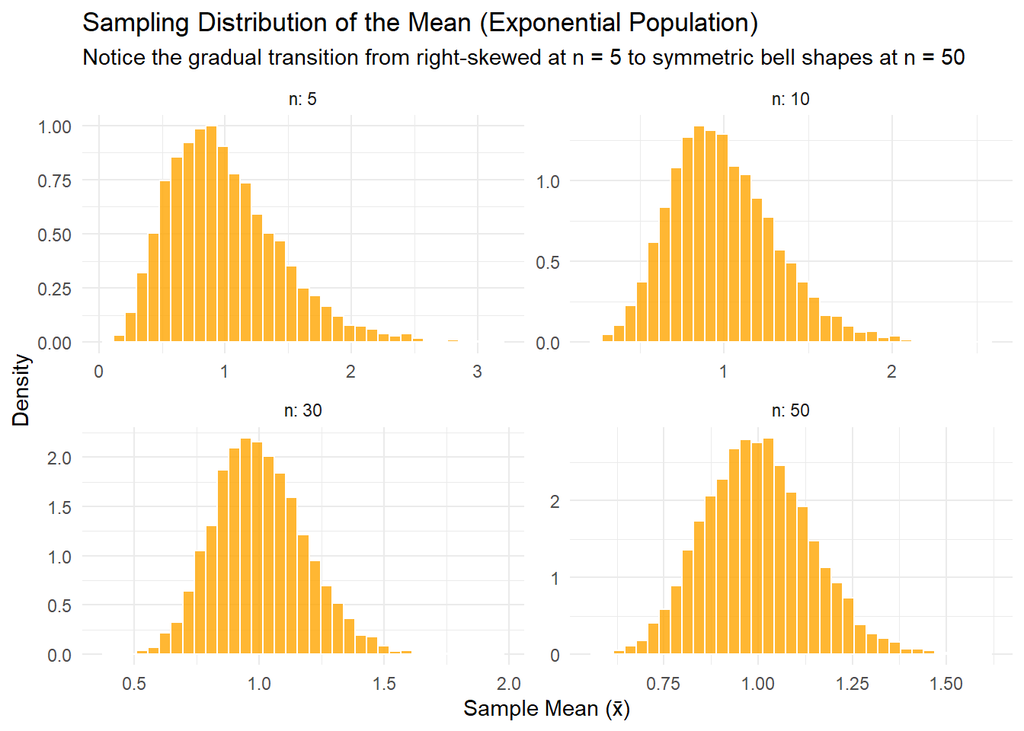

```r
ggplot(sim_data, aes(x = sample_mean)) +
  geom_histogram(aes(y = after_stat(density)), bins = 35, fill = "orange", color = "white", alpha = 0.8) +
  facet_wrap(~n, scales = "free", labeller = label_both) +
  theme_minimal() +
  labs(
    title = "Sampling Distribution of the Mean (Exponential Population)",
    subtitle = "Notice the gradual transition from right-skewed at n = 5 to symmetric bell shapes at n = 50",
    x = "Sample Mean (x̄)",
    y = "Density"
  )
```

As $n$ grows from $5$ to $50$, the histograms visually document the Central Limit Theorem in action: the strong right-tail asymmetry present at smaller sample sizes progressively smooths out into a symmetric, bell-shaped normal curve, while variance contracts according to $\text{SE} = \frac{1}{\sqrt{n}}$.

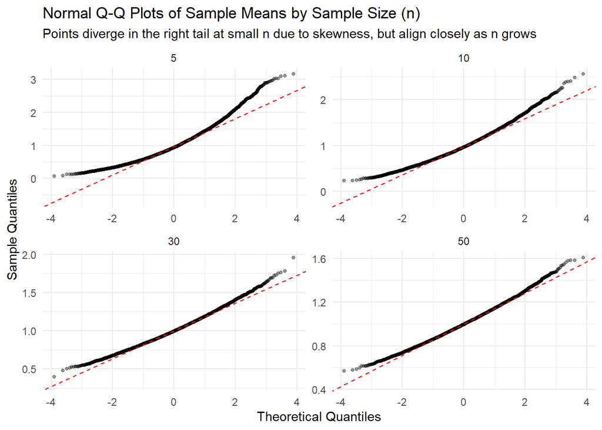

```r
library(ggplot2)

ggplot(sim_data, aes(sample = sample_mean)) +
  geom_qq(alpha = 0.4, size = 1) +
  geom_qq_line(color = "red", linetype = "dashed") +
  facet_wrap(~ n, scales = "free") +
  labs(
    title = "Normal Q-Q Plots of Sample Means by Sample Size (n)",
    subtitle = "Points diverge in the right tail at small n due to skewness, but align closely as n grows",
    x = "Theoretical Quantiles",
    y = "Sample Quantiles"
  ) +
  theme_minimal()
```

At small sample sizes ($n = 5$), the Q-Q plots display notable upward bending and tail divergence away from the red dashed line due to the parent population’s exponential skew. As sample sizes increase toward $n = 50$, the points align much more closely along the reference diagonal, confirming successful asymptotic convergence to normality.

## 5. Numerical Output

```r
summary_table <- sim_data %>%
  group_by(n) %>%
  summarise(
    Simulated_Mean = mean(sample_mean),
    Simulated_SD = sd(sample_mean),
    "Theoretical SE (σ/√n)" = theo_sigma / sqrt(as.numeric(as.character(first(n)))),
    Skewness = moments::skewness(sample_mean),
    Kurtosis = moments::kurtosis(sample_mean)
  )

knitr::kable(
  summary_table,
  caption = "Comparison of Simulated vs. Theoretical Metrics for Exponential Population",
  digits = 4,
  align = c("c", "c", "c", "c", "c")
)
```

Comparison of Simulated vs. Theoretical Metrics for Exponential Population

| n | Simulated_Mean | Simulated_SD | Theoretical SE (σ/√n) | Skewness | Kurtosis |
| --- | --- | --- | --- | --- | --- |
| 5 | 1.0027 | 0.4448 | 0.4472 | 0.9056 | 4.1454 |
| 10 | 0.9960 | 0.3125 | 0.3162 | 0.5997 | 3.4977 |
| 30 | 1.0032 | 0.1825 | 0.1826 | 0.3697 | 3.2081 |
| 50 | 1.0003 | 0.1418 | 0.1414 | 0.2760 | 3.1258 |

**Simulated Mean:** Stays consistently centered around $\mu = 1$ across all sample sizes, confirming that the sample mean remains an unbiased estimator even under heavy initial skewness.

**Skewness:** Starts high at small sample sizes (e.g., $\approx 0.9$ at $n = 5$) reflecting the parent distribution’s right tail, but progressively approaches $0$ as $n$ increases.

**Kurtosis:** Converges downward toward $3$ as the distribution normalizes and sheds its excessive tail weight with larger sample sizes.

## 6. In Summary

**1. What does the original population distribution look like?**

The parent population is an Exponential Distribution ($\lambda = 1$), which is continuous, heavily right-skewed, and has an exponential decay starting at zero.

**2. How quickly does the sampling distribution become approximately normal?**

Gradually. Due to the strong initial right-skew, small sample sizes ($n = 5, 10$) retain a visible right tail. Thanks to the Central Limit Theorem, it progressively smooths out into an approximate normal distribution by $n = 30$ to $n = 50$.

**3. How does the simulated mean compare with the theoretical mean?**

The simulated means stay extremely close to $\mu = 1$ across all $n$ (within $\pm 0.005$), confirming unbiased behavior over $10,000$ iterations.

**4. How does the simulated standard error compare with** $\text{SE}(\bar{x}) = \frac{\sigma}{\sqrt{n}}$?

The simulated standard deviations track the theoretical standard error formula ($\text{SE} = \frac{1}{\sqrt{n}}$) with high precision across all tested sample sizes.

**5. What evidence supports your conclusion that the distribution is approximately normal?**

Histograms transition from right-skewed curves into symmetric bell shapes, Q-Q plot points increasingly hug the red diagonal line, skewness decreases toward $0$, and kurtosis converges toward $3$.

**6. What limitations or surprises did you observe?**

The primary observation is the slower convergence rate caused by the strong skewness of the exponential distribution. Unlike normal or symmetric populations, small $n$ values show notable skew, requiring larger sample sizes like $n = 30$ or $n = 50$ for the Central Limit Theorem to effectively normalize the sampling distribution.